# ENUNCIADO

Valencian Telecommunications, SA (VALTEL) es una compañía prestadora de servicios de telecomunicaciones que se ha especializado en ciudadanos no nacionales residentes en España. Su propuesta de valor es ofrecer packs económicos focalizados en las llamadas internacionales y la itinerancia de datos (roaming) y tarifas flexibles de datos.

En su plan estratégico, se contempla la diversificación de servicios y se plantea el diseño de nuevas áreas de la compañía dedicadas a comercializar a través de internet bienes de interés para el colectivo de ciudadanos no nacionales. Por medio de encuestas a sus clientes, se ha detectado que la compra de vehículos para ciudadanos no nacionales puede ser un potencial nicho, y, concretamente, el mercado de coches de segunda mano.

VALTEL desea ofertar dentro de su app móvil un servicio que permita a sus clientes buscar vehículos en venta y ofrecerles un precio competitivo. Para conocer dicho precio, el área de I+D ha conseguido un dataset (Coches_Segunda_Mano.csv) con las ventas de vehículos de segunda mano y encarga al área de Ciencia de Datos la estimación del precio de cada vehículo para poder elaborar una tarifa competitiva.

```python
# Carga de librerias
import pandas as pd
import numpy as np
import seaborn as sns
import matplotlib.pyplot as plt
from sklearn.preprocessing import MinMaxScaler, StandardScaler, LabelEncoder
from sklearn.neighbors import KNeighborsRegressor
from pathlib import Path
from sklearn import linear_model
from sklearn.metrics import mean_squared_error, r2_score, mean_absolute_error
from sklearn.model_selection import train_test_split, GridSearchCV
import warnings
warnings.filterwarnings('ignore')
```

Vamos a utilizar la metodología CRISP-DM para abordar este proyecto.

# Entendimiento del negocio

Como se expone en el enunciado, lo que se pretende es estimar el precio de cada vehículo para elaborar una tarifa competitiva. Concretamente, lo que vamos a ilustrar es como estimar la variable Precio del dataset "Coches_Segunda_Mano.csv".

```python
# Lectura de datos
data = pd.read_csv('./Coches_Segunda_Mano.csv', index_col=False)
data.head()
```

|  | Marca | Modelo | Año | Combustible | CV | Cilindros | Transmisión | Tracción | Puertas | Mercado | Tamaño | Estilo | Consumo Carretera | Consumo Ciudad | Popularidad | Precio |
| --- | --- | --- | --- | --- | --- | --- | --- | --- | --- | --- | --- | --- | --- | --- | --- | --- |
| 0 | BMW | 1 Series M | 2011 | premium unleaded (required) | 335.0 | 6.0 | MANUAL | rear wheel drive | 2.0 | Factory Tuner,Luxury,High-Performance | Compact | Coupe | 26.0 | 19.0 | 3916 | 46135.0 |
| 1 | BMW | 1 Series | 2011 | premium unleaded (required) | 300.0 | 6.0 | MANUAL | rear wheel drive | 2.0 | Luxury,Performance | Compact | Convertible | 28.0 | 19.0 | 3916 | 40650.0 |
| 2 | BMW | 1 Series | 2011 | premium unleaded (required) | 300.0 | 6.0 | MANUAL | rear wheel drive | 2.0 | Luxury,High-Performance | Compact | Coupe | 28.0 | 20.0 | 3916 | 36350.0 |
| 3 | BMW | 1 Series | 2011 | premium unleaded (required) | 230.0 | 6.0 | MANUAL | rear wheel drive | 2.0 | Luxury,Performance | Compact | Coupe | 28.0 | 18.0 | 3916 | 29450.0 |
| 4 | BMW | 1 Series | 2011 | premium unleaded (required) | 230.0 | 6.0 | MANUAL | rear wheel drive | 2.0 | Luxury | Compact | Convertible | 28.0 | 18.0 | 3916 | 34500.0 |

# Entendimiento de los datos

## Descripción general de los datos

Vamos a ver un resumen de nuestro dataframe, nos interesa saber el número de columnas y filas con el que estamos trabajando, el tipo de cada variable y el número de entradas nulas.

```python
print(data.dtypes)
```

```
Marca                 object
Modelo                object
Año                    int64
Combustible           object
CV                   float64
Cilindros            float64
Transmisión           object
Tracción              object
Puertas              float64
Mercado               object
Tamaño                object
Estilo                object
Consumo Carretera    float64
Consumo Ciudad       float64
Popularidad            int64
Precio               float64
dtype: object
```

Sabemos que object representa una variable categórica, mientras que int64 es un número entero y float64 un número real.

```python
print(u'- El número de filas en el dataset es: {}'.format(data.shape[0]))
print(u'- El número de columnas en el dataset es: {}'.format(data.shape[1]))
print(u'- Los nombres de las variables son: {}'.format(list(data.columns)))
```

```
- El número de filas en el dataset es: 11914
- El número de columnas en el dataset es: 16
- Los nombres de las variables son: ['Marca', 'Modelo', 'Año', 'Combustible', 'CV', 'Cilindros', 'Transmisión', 'Tracción', 'Puertas', 'Mercado', 'Tamaño', 'Estilo', 'Consumo Carretera', 'Consumo Ciudad', 'Popularidad', 'Precio']
```

## Análisis univariante

Para comenzar el análisis univariante, vamos a crear dos dataframe separados con las variables cualitativas y las cuantitativas, donde nos preparamos los estadísticos básicos de cada una. Esto nos facilitará el estudio por separado.

```python
def analyse_data(data):
  data_types = dict(data.dtypes)
  numeric_cols = []
  categoric_cols = []
  for c,t in data_types.items():
    if t == np.float64:
      numeric_cols.append([c, 'Cuantitativa continua', data[c].mean(), data[c].min(), data[c].max(), data[c].median()])
    elif t == np.int64 or pd.Int64Dtype.is_dtype(t):
      numeric_cols.append([c, 'Cuantitativa discreta', data[c].mean(), data[c].min(), data[c].max(), data[c].median()])
    else:
      categoric_cols.append([c, f'Cualitativa', data[c].nunique()])
  n = pd.DataFrame(numeric_cols, columns=['Nombre', 'Tipo de variable', 'Media', 'Mínimo', 'Máximo', 'Mediana'])
  c = pd.DataFrame(categoric_cols, columns=['Nombre', 'Tipo de variable', 'Número de clases'])
  return n, c

numeric_types, categoric_types = analyse_data(data)
print("Finalizado OK")
```

```
Finalizado OK
```

### Variables cualitativas

Ejecutando la siguiente celda, permite observar las columnas con datos cualitativos junto con el número de clases de cada una de ellas.

```python
print(categoric_types.to_string(index=False))
```

```
     Nombre Tipo de variable  Número de clases
      Marca      Cualitativa                48
     Modelo      Cualitativa               915
Combustible      Cualitativa                10
Transmisión      Cualitativa                 5
   Tracción      Cualitativa                 4
    Mercado      Cualitativa                71
     Tamaño      Cualitativa                 3
     Estilo      Cualitativa                16
```

Eliminamos las variables Modelo y Mercado de nuestro análisis, dado que tienen demasiado número de clases.

```python
categoric_types2 = categoric_types.drop(categoric_types[(categoric_types['Nombre'] == 'Modelo') | (categoric_types['Nombre'] == "Mercado")].index)
print(categoric_types2.to_string(index=False))
```

```
     Nombre Tipo de variable  Número de clases
      Marca      Cualitativa                48
Combustible      Cualitativa                10
Transmisión      Cualitativa                 5
   Tracción      Cualitativa                 4
     Tamaño      Cualitativa                 3
     Estilo      Cualitativa                16
```

Visualizamos las variables cualitativas para conocer su distribución de valores:

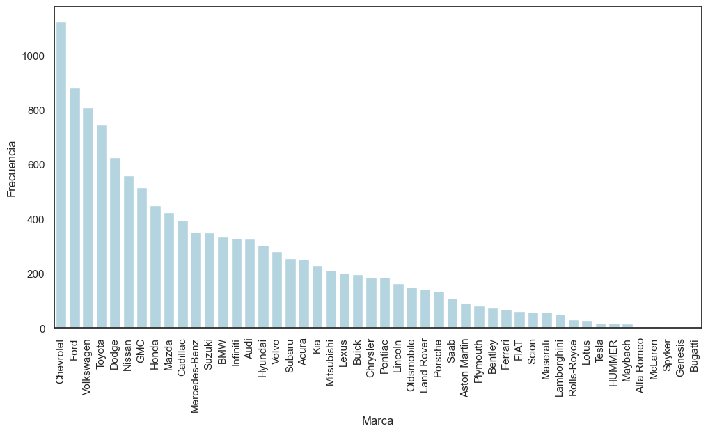

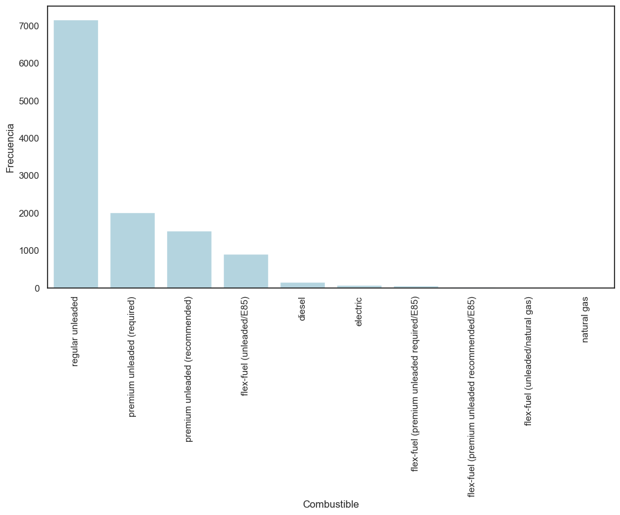

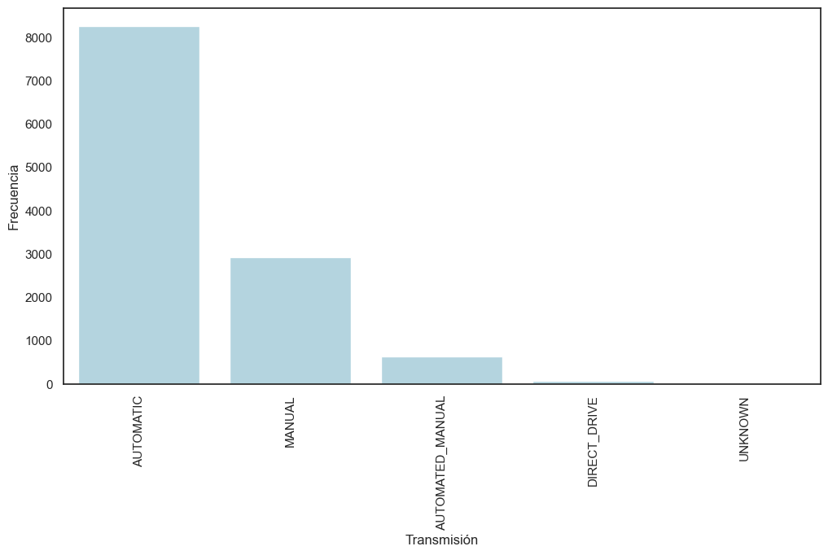

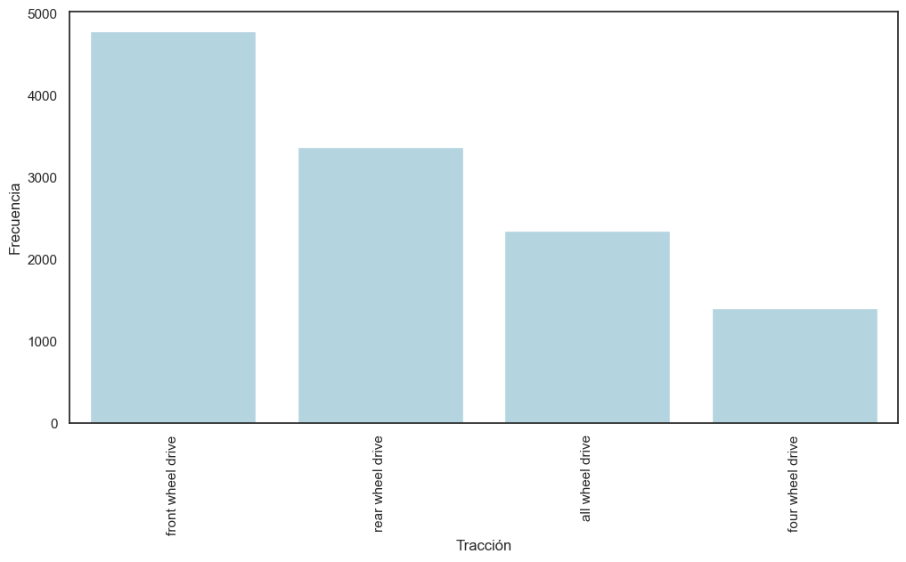

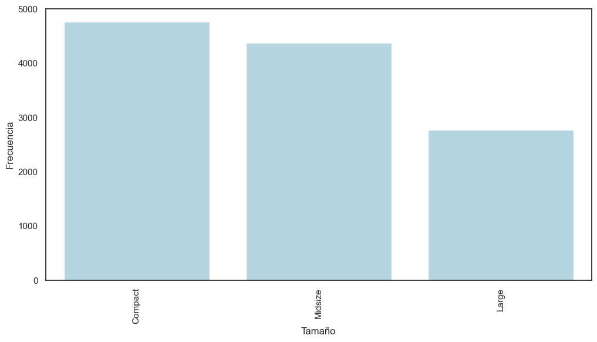

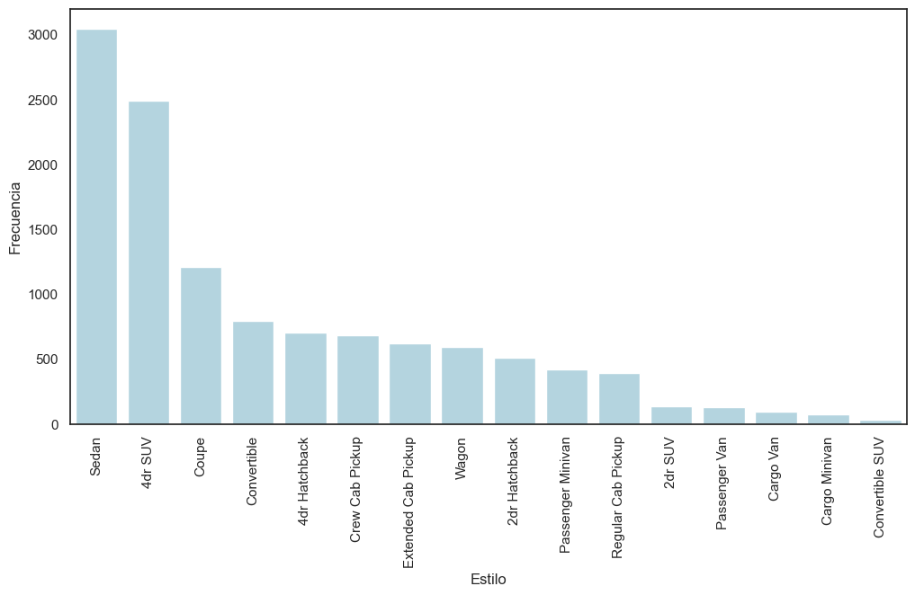

```python
for i in categoric_types2.index:
      if categoric_types2['Nombre'][i]:
            column = categoric_types['Nombre'][i]
            fig, ax = plt.subplots(figsize=(12,6))
            chart = sns.countplot(data=data, x=column, color='lightblue', order = data[column].value_counts().index)
            chart.set_xticklabels(chart.get_xticklabels(), rotation=90)
            chart.set_ylabel('Frecuencia')
            plt.show()
```

### Variables cuantitativas

Procedamos de manera análoga con las variables cuantitativas y vemos sus estadísticos básicos:

```python
print(numeric_types.to_string(index=False))
```

```
           Nombre      Tipo de variable        Media  Mínimo    Máximo  Mediana
              Año Cuantitativa discreta  2010.384338  1990.0    2017.0   2015.0
               CV Cuantitativa continua   249.386070    55.0    1001.0    227.0
        Cilindros Cuantitativa continua     5.628829     0.0      16.0      6.0
          Puertas Cuantitativa continua     3.436093     2.0       4.0      4.0
Consumo Carretera Cuantitativa continua    26.637485    12.0     354.0     26.0
   Consumo Ciudad Cuantitativa continua    19.733255     7.0     137.0     18.0
      Popularidad Cuantitativa discreta  1554.911197     2.0    5657.0   1385.0
           Precio Cuantitativa continua 40594.737032  2000.0 2065902.0  29995.0
```

Para conocer su distribución las visualizamos cada una con un histograma:

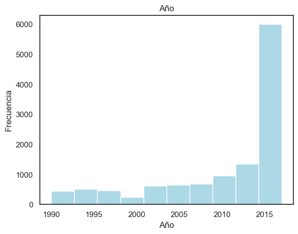

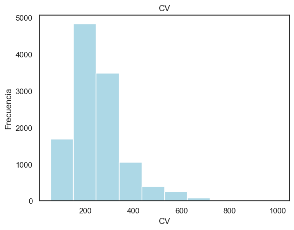

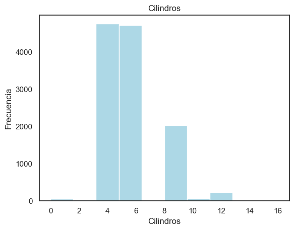

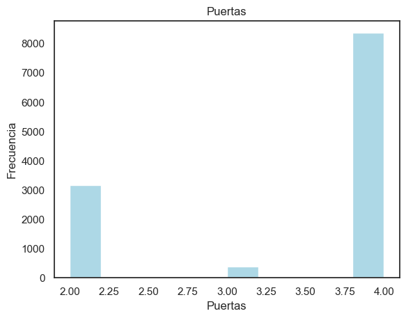

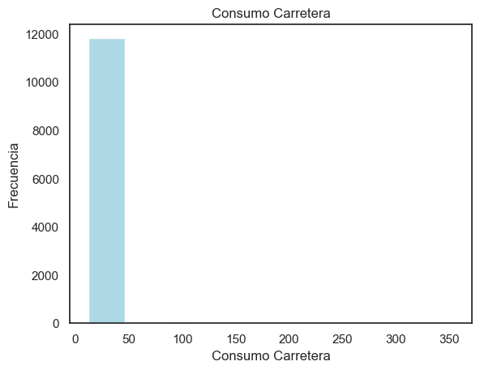

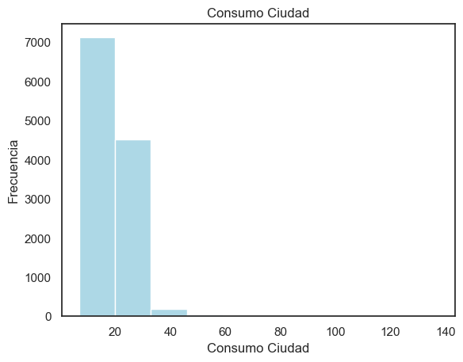

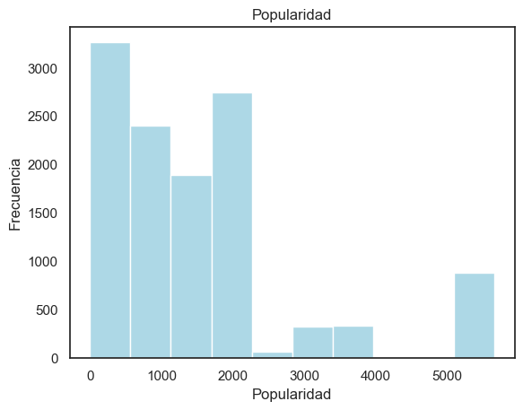

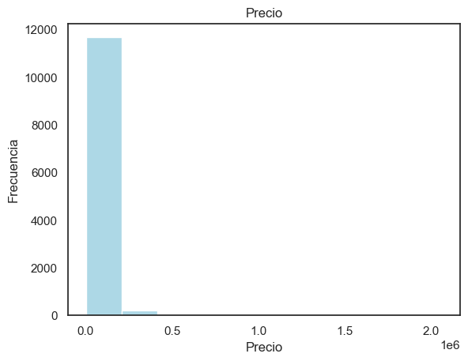

```python
for i in numeric_types.index:
    column = numeric_types['Nombre'][i]
    plt.hist(data[column], color='lightblue')
    plt.xlabel(column)
    plt.ylabel('Frecuencia')
    plt.title(column)
    plt.show()
```

## Análisis bivariante

Ahora, vamos a realizar el análisis de cada variable frente a la variable objetivo que en este caso es el Precio.

### Variables cualitativas vs. Precio

Para conocer el comportamiento de las variables cualitativas frente a la variable objetivo vamos a utilizar el BarPlot.

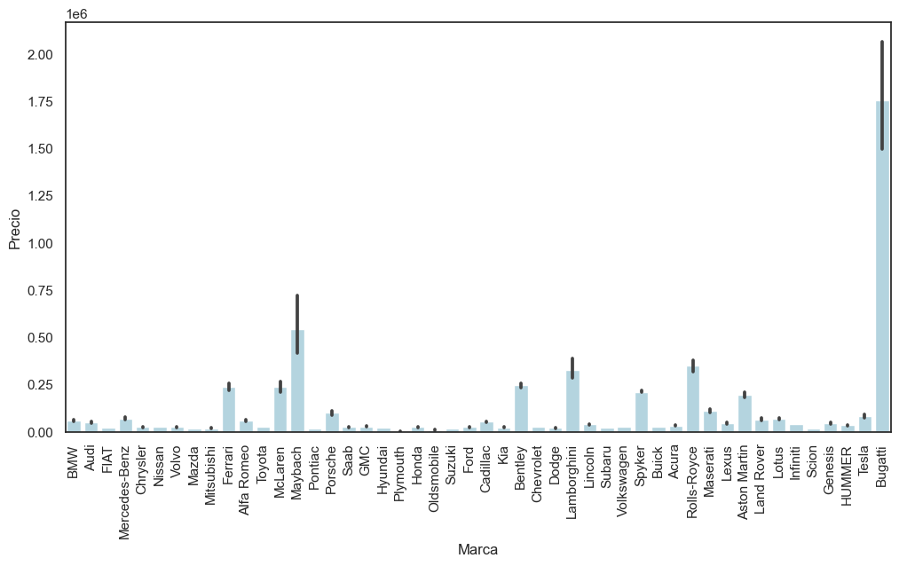

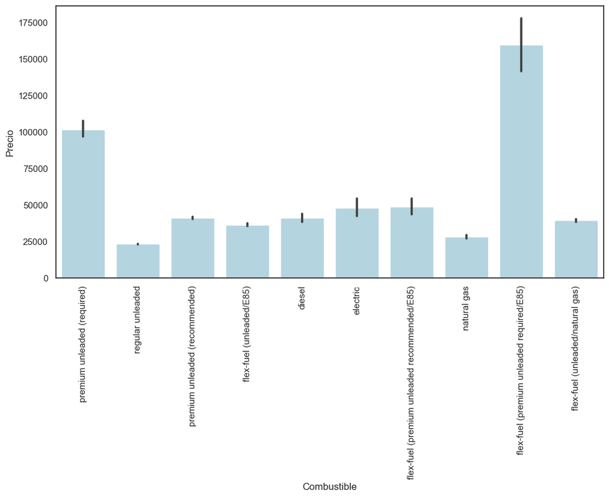

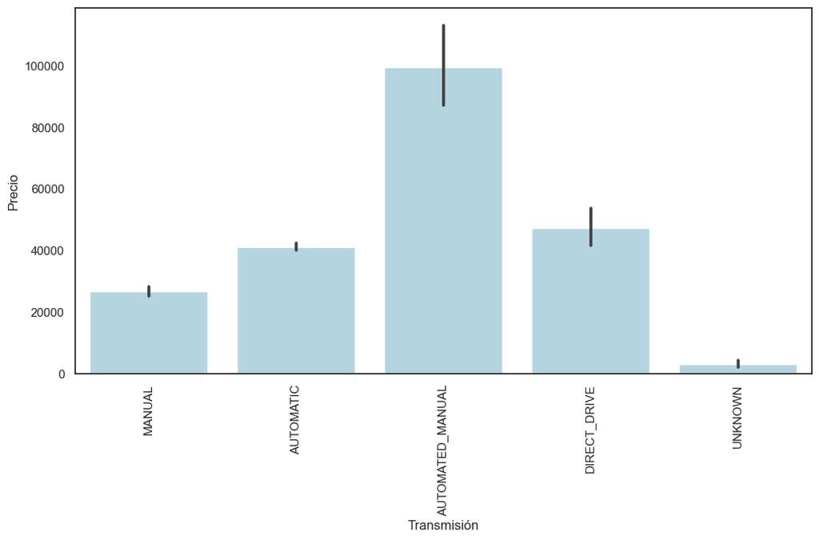

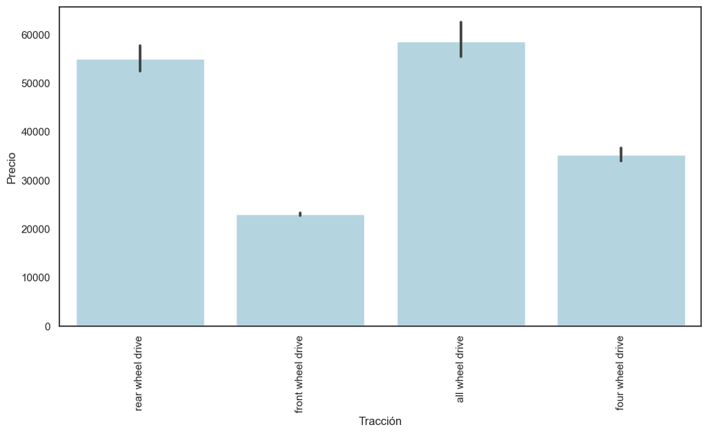

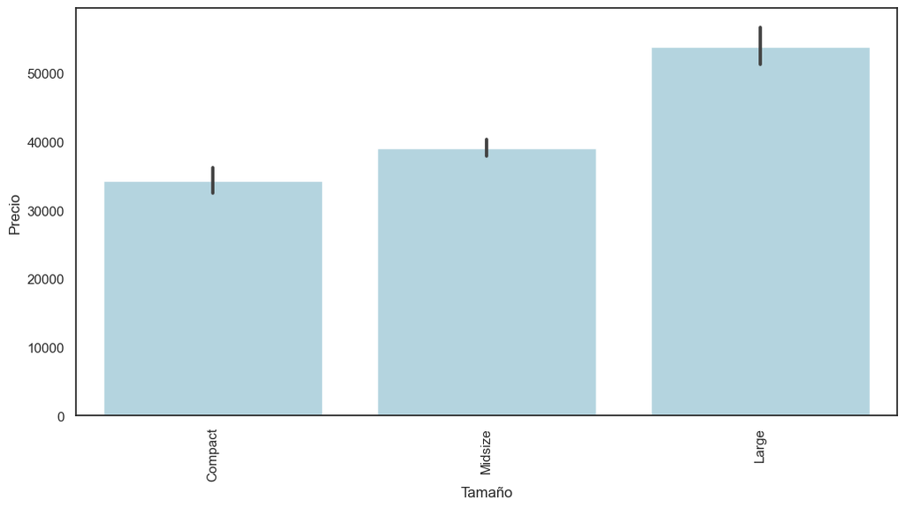

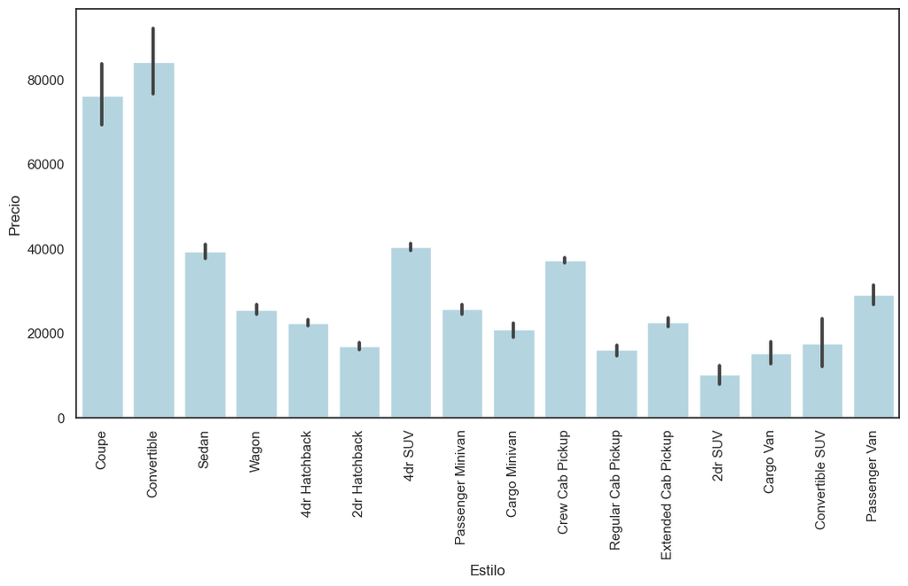

```python
for i in categoric_types2.index:
      x_axis = categoric_types2['Nombre'][i]
      y_axis = 'Precio'
      fig, ax = plt.subplots(figsize=(12,6))
      chart = sns.barplot(data=data, x=x_axis, y=y_axis, color='lightblue')
      chart.set_xticklabels(chart.get_xticklabels(), rotation=90)
      plt.show()
```

### Variables cuantitativas vs. Precio

Para conocer el comportamiento de las variables cuantitativas frente a la variable objetivo vamos a utilizar el ScatterPlot.

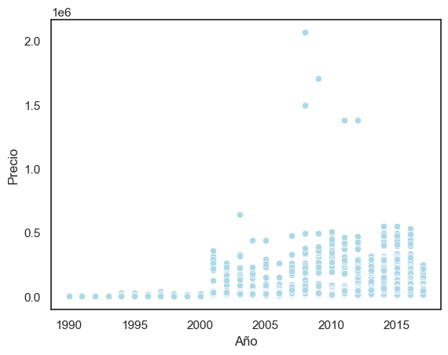

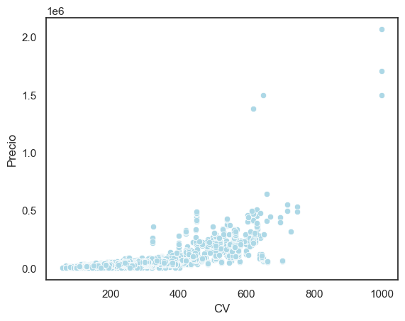

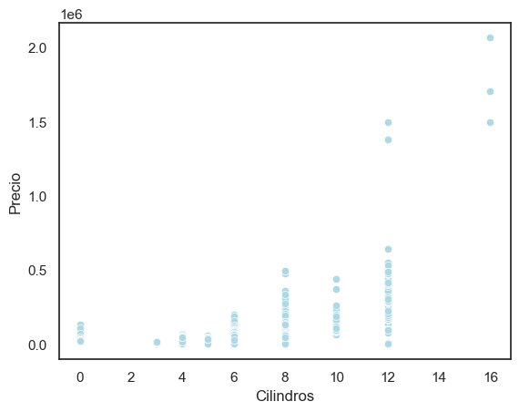

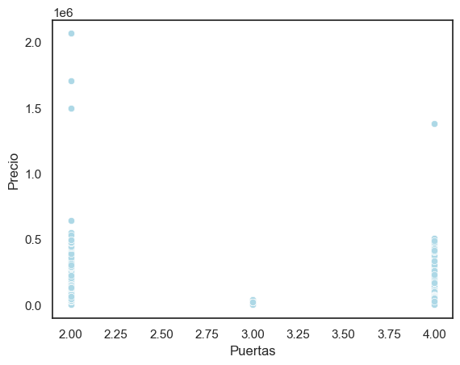

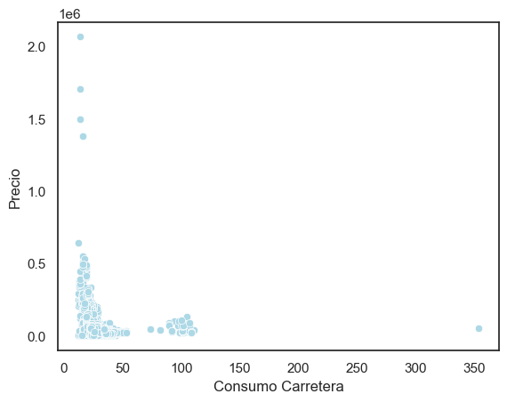

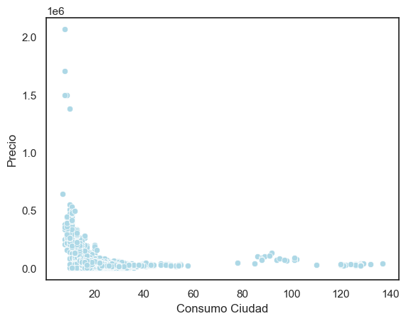

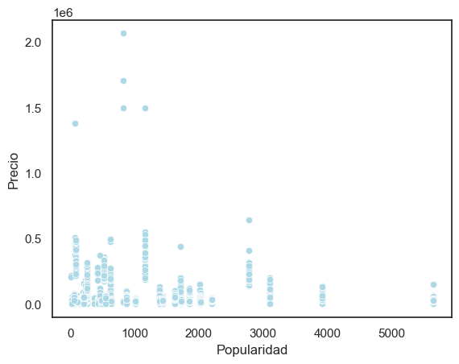

```python
for i in numeric_types.index:
    if numeric_types['Nombre'][i] != 'Precio':
      x_axis = numeric_types['Nombre'][i]
      y_axis = 'Precio'
      fig, ax = plt.subplots()
      chart = sns.scatterplot(data=data, x=x_axis, y=y_axis, color='lightblue')
      plt.show()
```

## Análisis multivariante

```python
numeric_data = data.select_dtypes(include=['float', 'int'])
numeric_data = numeric_data.drop(columns=['Precio'])
numeric_data
```

|  | Año | CV | Cilindros | Puertas | Consumo Carretera | Consumo Ciudad | Popularidad |
| --- | --- | --- | --- | --- | --- | --- | --- |
| 0 | 2011 | 335.0 | 6.0 | 2.0 | 26.0 | 19.0 | 3916 |
| 1 | 2011 | 300.0 | 6.0 | 2.0 | 28.0 | 19.0 | 3916 |
| 2 | 2011 | 300.0 | 6.0 | 2.0 | 28.0 | 20.0 | 3916 |
| 3 | 2011 | 230.0 | 6.0 | 2.0 | 28.0 | 18.0 | 3916 |
| 4 | 2011 | 230.0 | 6.0 | 2.0 | 28.0 | 18.0 | 3916 |
| ... | ... | ... | ... | ... | ... | ... | ... |
| 11909 | 2012 | 300.0 | 6.0 | 4.0 | 23.0 | 16.0 | 204 |
| 11910 | 2012 | 300.0 | 6.0 | 4.0 | 23.0 | 16.0 | 204 |
| 11911 | 2012 | 300.0 | 6.0 | 4.0 | 23.0 | 16.0 | 204 |
| 11912 | 2013 | 300.0 | 6.0 | 4.0 | 23.0 | 16.0 | 204 |
| 11913 | 2006 | 221.0 | 6.0 | 4.0 | 26.0 | 17.0 | 61 |

11914 rows × 7 columns

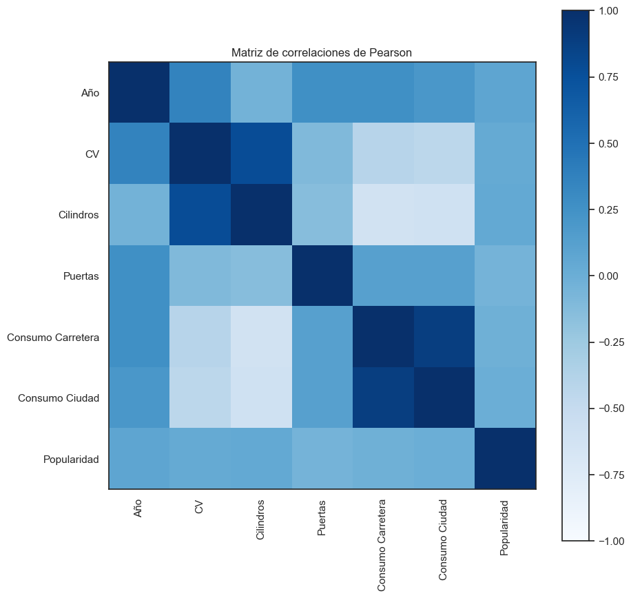

```python
matriz_correlaciones = numeric_data.corr(method='pearson')
n_ticks = len(numeric_data.columns)
plt.figure(figsize=(10, 10))
plt.xticks(range(n_ticks), numeric_data.columns, rotation = 'vertical')
plt.yticks(range(n_ticks), numeric_data.columns)
plt.colorbar(plt.imshow(matriz_correlaciones, interpolation='nearest', vmin=-1., vmax=1., cmap=plt.get_cmap('Blues')))
_ = plt.title('Matriz de correlaciones de Pearson')
plt.show()
```

## Calidad del dato

### Detección de valores nulos

```python
print("Número de filas válidas por columna:")
print(data.count().to_string())
print()
```

```
Número de filas válidas por columna:
Marca                11914
Modelo               11914
Año                  11914
Combustible          11911
CV                   11845
Cilindros            11884
Transmisión          11914
Tracción             11914
Puertas              11908
Mercado               8172
Tamaño               11914
Estilo               11914
Consumo Carretera    11914
Consumo Ciudad       11914
Popularidad          11914
Precio               11914
```

### Detección de valores atípicos

Analizamos los valores atípicos de las variables cuantitativas para descartarlos posteriormente.

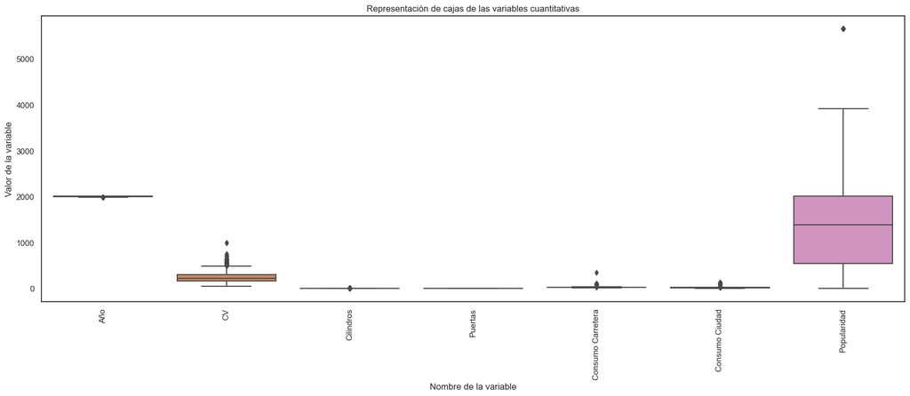

```python
plt.figure(figsize=(21,7))
ax = sns.boxplot(data=numeric_data)
ax.set_xticklabels(ax.get_xticklabels(), rotation= 90)
plt.title(u'Representación de cajas de las variables cuantitativas')
plt.ylabel(u'Valor de la variable')
_ = plt.xlabel(u'Nombre de la variable')
```

# Preprocesamiento de los datos

## Limpieza de datos

### Valores faltantes

```python
print("Eliminando datos nulos:")
print()
data = data.dropna()
```

```
Eliminando datos nulos:
```

```python
data = data.astype({"Puertas": int})
```

```python
print("Número de filas válidas por columna:")
print(data.count().to_string())
```

```
Número de filas válidas por columna:
Marca                8084
Modelo               8084
Año                  8084
Combustible          8084
CV                   8084
Cilindros            8084
Transmisión          8084
Tracción             8084
Puertas              8084
Mercado              8084
Tamaño               8084
Estilo               8084
Consumo Carretera    8084
Consumo Ciudad       8084
Popularidad          8084
Precio               8084
```

### Valores duplicados

```python
print(f"Número de filas: {data.shape[0]}")
print(f"Número de columnas: {data.shape[1]}")
print()
print("Eliminando filas con valores duplicados...")
data = data.drop_duplicates()
print()
print(f"Número de filas: {data.shape[0]}")
print(f"Número de columnas: {data.shape[1]}")
```

```
Número de filas: 8084
Número de columnas: 16

Eliminando filas con valores duplicados...

Número de filas: 7735
Número de columnas: 16
```

### Valores atípicos

Con el siguiente código eliminamos los valores atípicos indicando los nombres de las columnas en el vector columns_with_outliers

```
Número de filas (con valores atípicos): 7735
Eliminando valores atípicos...
Número de filas (sin valores atípicos): 5997

Datos Cuantitativos:
           Nombre      Tipo de variable        Media  Mínimo   Máximo  Mediana
              Año Cuantitativa discreta  2013.468901  2001.0   2017.0   2015.0
               CV Cuantitativa continua   269.586460    79.0    521.0    272.0
        Cilindros Cuantitativa continua     5.600800     4.0      8.0      6.0
          Puertas Cuantitativa discreta     3.497749     2.0      4.0      4.0
Consumo Carretera Cuantitativa continua    26.653660    14.0     42.0     26.0
   Consumo Ciudad Cuantitativa continua    19.235451     9.0     31.0     19.0
      Popularidad Cuantitativa discreta  1229.969485     2.0   3916.0    873.0
           Precio Cuantitativa continua 43976.757045  9299.0 363000.0  36715.0
```

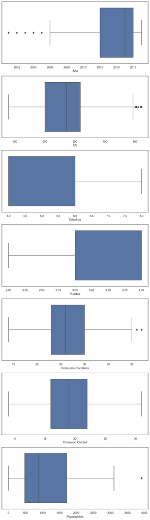

```python
columns_with_outliers = ['Año', 'CV', 'Cilindros', 'Puertas', 'Consumo Carretera', 'Consumo Ciudad', 'Popularidad']
print(f"Número de filas (con valores atípicos): {data.shape[0]}")
print("Eliminando valores atípicos...")
Q1 = data[columns_with_outliers].quantile(0.25)
Q3 = data[columns_with_outliers].quantile(0.75)
IQR = Q3 - Q1
data2 = data[~((data[columns_with_outliers] < (Q1 - 1.5 * IQR)) | (data[columns_with_outliers] > (Q3 + 1.5 * IQR))).any(axis=1)]
print(f"Número de filas (sin valores atípicos): {data2.shape[0]}")

# Assuming the function `analyse_data()` is defined elsewhere
numeric_types, categoric_types = analyse_data(data2)
print()
print("Datos Cuantitativos:")
print(numeric_types.to_string(index=False))
print()

fig, axs = plt.subplots(figsize=(10, 35), nrows=7)
sns.boxplot(x=data2['Año'], ax=axs[0])
sns.boxplot(x=data2['CV'], ax=axs[1])
sns.boxplot(x=data2['Cilindros'], ax=axs[2])
sns.boxplot(x=data2['Puertas'], ax=axs[3])
sns.boxplot(x=data2['Consumo Carretera'], ax=axs[4])
sns.boxplot(x=data2['Consumo Ciudad'], ax=axs[5])
sns.boxplot(x=data2['Popularidad'], ax=axs[6])

plt.show()
```

## Construir

Normalizamos la variable Consumo Ciudad, Consumo Carretera y CV

```python
scaler = MinMaxScaler()
data2[['Consumo Ciudad']] = scaler.fit_transform(data2[['Consumo Ciudad']])
data2[['Consumo Carretera']] = scaler.fit_transform(data2[['Consumo Carretera']])
data2[['CV']] = scaler.fit_transform(data2[['CV']])
data2[['Popularidad']] = scaler.fit_transform(data2[['Popularidad']])
data2.head()
```

|  | Marca | Modelo | Año | Combustible | CV | Cilindros | Transmisión | Tracción | Puertas | Mercado | Tamaño | Estilo | Consumo Carretera | Consumo Ciudad | Popularidad | Precio |
| --- | --- | --- | --- | --- | --- | --- | --- | --- | --- | --- | --- | --- | --- | --- | --- | --- |
| 0 | BMW | 1 Series M | 2011 | premium unleaded (required) | 0.579186 | 6.0 | MANUAL | rear wheel drive | 2 | Factory Tuner,Luxury,High-Performance | Compact | Coupe | 0.428571 | 0.454545 | 1.0 | 46135.0 |
| 1 | BMW | 1 Series | 2011 | premium unleaded (required) | 0.500000 | 6.0 | MANUAL | rear wheel drive | 2 | Luxury,Performance | Compact | Convertible | 0.500000 | 0.454545 | 1.0 | 40650.0 |
| 2 | BMW | 1 Series | 2011 | premium unleaded (required) | 0.500000 | 6.0 | MANUAL | rear wheel drive | 2 | Luxury,High-Performance | Compact | Coupe | 0.500000 | 0.500000 | 1.0 | 36350.0 |
| 3 | BMW | 1 Series | 2011 | premium unleaded (required) | 0.341629 | 6.0 | MANUAL | rear wheel drive | 2 | Luxury,Performance | Compact | Coupe | 0.500000 | 0.409091 | 1.0 | 29450.0 |
| 4 | BMW | 1 Series | 2011 | premium unleaded (required) | 0.341629 | 6.0 | MANUAL | rear wheel drive | 2 | Luxury | Compact | Convertible | 0.500000 | 0.409091 | 1.0 | 34500.0 |

## Formatear

Como la mayor parte de modelos de machine learning en scikit-learn necesitan variables numéricas para funcionar, vamos a utilizar una técnica de codificación que nos permite transformar variables categóricas en numéricas.

```python
# Lista de variables categóricas
data2.select_dtypes(exclude=['number']).columns
```

```
Index(['Marca', 'Modelo', 'Combustible', 'Transmisión', 'Tracción', 'Mercado',
       'Tamaño', 'Estilo'],
      dtype='object')
```

```python
# Utilizamos el método de Label Encoder
le = LabelEncoder()
```

```python
# Codificamos con label encoder
data2['Marca'] = le.fit_transform(data2['Marca'].values)
data2['Modelo'] = le.fit_transform(data2['Modelo'].values)
data2['Combustible'] = le.fit_transform(data2['Combustible'].values)
data2['Transmisión'] = le.fit_transform(data2['Transmisión'].values)
data2['Tracción'] = le.fit_transform(data2['Tracción'].values)
data2['Mercado'] = le.fit_transform(data2['Mercado'].values)
data2['Tamaño'] = le.fit_transform(data2['Tamaño'].values)
data2['Estilo'] = le.fit_transform(data2['Estilo'].values)

# Comprobamos que no hay variables categóricas
data2.select_dtypes(exclude=['number']).columns
```

```
Index([], dtype='object')
```

Probemos ahora a detectar posibles correlaciones:

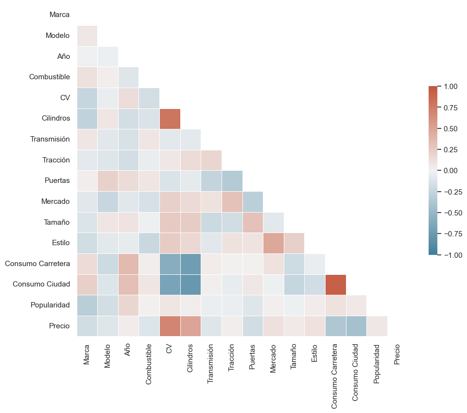

```python
corr = data2.corr()
mask = np.triu(np.ones_like(corr, dtype=bool))
f, ax = plt.subplots(figsize=(11, 9))
cmap = sns.diverging_palette(230, 20, as_cmap=True)
sns.set_theme(style="white")
sns.heatmap(corr, mask=mask, cmap=cmap, vmax=1, vmin=-1, center=0,
            square=True, linewidths=.5, cbar_kws={"shrink": .5})
```

Como se puede observar las dos variables cuantitativas, CV y Cilindros son las que más correlacionadas se encuentran con nuestra variable objetivo Precio.

# Desarrollo y Evaluación del modelo

Como queremos estimar una variable cuantitativa, es un problema de regresión

## Regresión lineal simple

Vamos a probar lo más sencillo, que es utilizar una regresión lineal con la variable explicativa que más correlación presenta (CV):

```
Error cuadrático medio (MSE): 0.0033
Coeficiente de determinación (R2): 0.5170
```

[figure not shown]

```python
x_cols = ['CV']
y_cols = ['Precio']

# Normalizamos las dos variables, para poder interpretar mejor los resultados
scaler = MinMaxScaler()
X = scaler.fit_transform(data2[x_cols])
y = scaler.fit_transform(data2[y_cols])

# Generamos el dataset de entrenamiento y el de test
X_train, X_test, y_train, y_test = train_test_split(X, y, test_size=0.20, random_state=47)

# Entrenamos el modelo
lg = linear_model.LinearRegression()
lg.fit(X_train, y_train)

# Evaluamos el modelo
y_pred = lg.predict(X_test)

print(f"Error cuadrático medio (MSE): {mean_squared_error(y_test, y_pred):.4f}")
print(f"Coeficiente de determinación (R2): {r2_score(y_test, y_pred):.4f}")

fig, ax = plt.subplots(figsize=(12,8))
plt.scatter(y_pred, y_test,  color='lightblue')
plt.plot(y_pred, y_pred, color='black', linewidth=3)

plt.xlabel('Precio Estimado')
plt.ylabel('Precio Real')
plt.show()
```